# Fourteen years of continuous soil moisture records from plant and biocrust-dominated microsites

Joaquín Moreno<sup>1,⋆</sup>, Sergio Asensio<sup>1</sup>, Miguel Berdugo<sup>1,2</sup>, Beatriz Gozalo<sup>1</sup>, Victoria Ochoa<sup>1</sup>, David Sánchez-Pescador<sup>3,4</sup>, Blas M. Benito<sup>1,†</sup>, and Fernando T. Maestre<sup>1,5</sup>

<sup>1</sup> Instituto Multidisciplinar para el Estudio del Medio “Ramon Margalef”, Universidad de Alicante, Edificio Nuevos Institutos, Carretera de San Vicente del Raspeig s/n, 03690 San Vicente del Raspeig, Spain.  
<sup>2</sup> Institut Department of Environmental Systems Science, ETH Zürich. Universitätstrasse 16, 8092 Zurich, Switzerland.  
<sup>3</sup> Departamento de Farmacología, Farmacognosia y Botánica, Facultad de Farmacia, Universidad Complutense de Madrid, Madrid, Spain.  
<sup>4</sup> Departamento de Biología y Geología, Física y Química Inorgánica, Escuela Superior de Ciencias Experimentales y Tecnológicas, Universidad Rey Juan Carlos, Calle Tulipán s/n, 28933 Móstoles, Madrid, Spain.  
<sup>5</sup> Departamento de Ecología, Universidad de Alicante, Carretera de San Vicente del Raspeig s/n, 03690 San Vicente del Raspeig, Alicante, Spain.

<sup>⋆</sup> Corresponding author: Joaquín Moreno <joaquin.moreno@ua.es>

† Code author: Blas M. Benito <blasbenito@gmail.com>

# 1 Summary

The **MOISCRUST** database and this reproducible notebook are distributed under the license [Creative Commons Attribution-NonCommercial-ShareAlike 4.0 International](https://creativecommons.org/licenses/by/4.0/legalcode).

# 2 Reproducing this notebook

This reproducible workflow is available as an interactive Rstudio notebook in the file **moiscrust.Rmd** stored in this repository. It is packaged with renv to facilitate reproducibility. That means that the R package versions originally used to run the notebook are already installed in the `renv` folder of the repository. To run it in your computer, execute the code chunk below to prepare the session. You will need to replace `eval = FALSE` with `eval = TRUE` in the header of the code chunk.

```r
install.packages("renv")
renv::restore()
```

# 3 Data loading and preparation

## 3.1 Loading the required libraries

The following R libraries are required to run this notebook.

```r
library("data.table")
library("dplyr")
library("magrittr")
library("tidyr")
library("ggplot2")
library("kableExtra")
library("foreach")
library("doParallel")
library("readr")
library("writexl")
library("RSQLite")
library("zip")
library("knitr")
library("DBI")
```

## 3.2 Value to replace negative values with

Humidity sensors may drift over time, and yield negative values instead of zero. These negative values can be either be interpreted as malfunctions, or as zero humidity. The variable below is used to replace negative soil humidity values throughout this workflow. When set to `NA`, the variable `replace.negatives.with` represents sensor malfunctions. It should be set to `0` if negatives are interpreted as zero humidity.

```r
replace.negatives.with <- NA
```

## 3.3 Loading and preparing the raw data

The raw data, stored in the file *moiscrust_raw.csv* was compiled by the members of [Maestre Lab](https://maestrelab.com/en/) from the data provided by the soil moisture sensors.

```r
#loading the raw moiscrust dataset
moiscrust <- data.table::fread(file = "data/moiscrust_raw.csv") %>%
  as.data.frame()
```

## 3.4 Formatting dates and times

The raw data contains two fields representing time, namely *date* (year, month, and day), and *time* (hour, minute, and seconds). Below we format these fields according to the POSIX standard, and add new fields adding criteria to subset the data by time:

- *date_time*: Date and time in POSIX format.
- *date_time_id*: Unique identificator for each *date_time*.
- *year*: Year number.
- *year_day*: Day of the year.
- *month*: Month number.
- *month_day*: Day of the month.
- *week*: Week of the year.
- *week_day*: Day of the week.

```r
#date to Year-month-day
moiscrust$date <- format(
  as.POSIXct(
    strptime(
      moiscrust$date,
      "%d/%m/%Y",
      tz = ""
      )
    ),
  format = "%Y-%m-%d"
  )

#time to Hour-Minute
moiscrust$time <- format(
  as.POSIXct(
    strptime(
      moiscrust$time,
      "%H:%M:%S",
      tz = ""
      )
    ),
  format = "%H:%M"
  )

#joining date and time
moiscrust$date_time <- as.POSIXct(
  paste(
    moiscrust$date,
    moiscrust$time
    ),
  format="%Y-%m-%d %H:%M"
  )

#unique id for each observation
moiscrust$date_time_id <- 1:nrow(moiscrust)

#creating year, month, and day related columns
moiscrust$year <- lubridate::year(moiscrust$date)
moiscrust$year_day <- lubridate::yday(moiscrust$date)
moiscrust$month <- lubridate::month(moiscrust$date)
moiscrust$month_day <- lubridate::mday(moiscrust$date)
moiscrust$week <- lubridate::week(moiscrust$date)
moiscrust$week_day <- lubridate::wday(moiscrust$date)
```

## 3.5 Reordering columns and arranging into long format

At this point, the *MOISCRUST* data has 15 columns representing soils moisture measures (five microsites per three replicates per microsite), and 10 columns representing *time*. The data is also structured in what is known as a [“wide format”](https://sejdemyr.github.io/r-tutorials/basics/wide-and-long/). Below we reorder these columns to facilitate arranging the data into a “long format”.

```r
#names of the sensors
sensors <- c(
  "retama_1",
  "retama_2",
  "retama_3",
  "stipa_1",
  "stipa_2",
  "stipa_3",
  "bare_soil_1",
  "bare_soil_2",
  "bare_soil_3",
  "biocrust_medium_1",
  "biocrust_medium_2",
  "biocrust_medium_3",
  "biocrust_high_1",
  "biocrust_high_2",
  "biocrust_high_3"
)

#reordering columns of moiscrust to have time in the left side
moiscrust <- moiscrust[, c(
  "date_time",
  "date_time_id",
  "date",
  "time",
  "year",
  "year_day",
  "month",
  "month_day",
  "week",
  "week_day",
  sensors
)]

#to long format
moiscrust_long <- tidyr::pivot_longer(
  moiscrust,
  cols = all_of(sensors),
  names_to = "sensor",
  values_to = "soil_moisture"
)
```

| date_time | date_time_id | date | time | year | year_day | month | month_day | week | week_day | sensor | soil_moisture |
| --- | --- | --- | --- | --- | --- | --- | --- | --- | --- | --- | --- |
| 2006-11-17 18:00:00 | 1 | 2006-11-17 | 18:00 | 2006 | 321 | 11 | 17 | 46 | 6 | retama_1 | 0.197 |
| 2006-11-17 18:00:00 | 1 | 2006-11-17 | 18:00 | 2006 | 321 | 11 | 17 | 46 | 6 | retama_2 | NA |
| 2006-11-17 18:00:00 | 1 | 2006-11-17 | 18:00 | 2006 | 321 | 11 | 17 | 46 | 6 | retama_3 | NA |
| 2006-11-17 18:00:00 | 1 | 2006-11-17 | 18:00 | 2006 | 321 | 11 | 17 | 46 | 6 | stipa_1 | 0.132 |
| 2006-11-17 18:00:00 | 1 | 2006-11-17 | 18:00 | 2006 | 321 | 11 | 17 | 46 | 6 | stipa_2 | NA |
| 2006-11-17 18:00:00 | 1 | 2006-11-17 | 18:00 | 2006 | 321 | 11 | 17 | 46 | 6 | stipa_3 | NA |
| 2006-11-17 18:00:00 | 1 | 2006-11-17 | 18:00 | 2006 | 321 | 11 | 17 | 46 | 6 | bare_soil_1 | 0.232 |
| 2006-11-17 18:00:00 | 1 | 2006-11-17 | 18:00 | 2006 | 321 | 11 | 17 | 46 | 6 | bare_soil_2 | NA |
| 2006-11-17 18:00:00 | 1 | 2006-11-17 | 18:00 | 2006 | 321 | 11 | 17 | 46 | 6 | bare_soil_3 | NA |
| 2006-11-17 18:00:00 | 1 | 2006-11-17 | 18:00 | 2006 | 321 | 11 | 17 | 46 | 6 | biocrust_medium_1 | 0.205 |
| 2006-11-17 18:00:00 | 1 | 2006-11-17 | 18:00 | 2006 | 321 | 11 | 17 | 46 | 6 | biocrust_medium_2 | NA |
| 2006-11-17 18:00:00 | 1 | 2006-11-17 | 18:00 | 2006 | 321 | 11 | 17 | 46 | 6 | biocrust_medium_3 | NA |
| 2006-11-17 18:00:00 | 1 | 2006-11-17 | 18:00 | 2006 | 321 | 11 | 17 | 46 | 6 | biocrust_high_1 | 0.121 |
| 2006-11-17 18:00:00 | 1 | 2006-11-17 | 18:00 | 2006 | 321 | 11 | 17 | 46 | 6 | biocrust_high_2 | NA |
| 2006-11-17 18:00:00 | 1 | 2006-11-17 | 18:00 | 2006 | 321 | 11 | 17 | 46 | 6 | biocrust_high_3 | NA |
| 2006-11-17 20:00:00 | 2 | 2006-11-17 | 20:00 | 2006 | 321 | 11 | 17 | 46 | 6 | retama_1 | 0.195 |
| 2006-11-17 20:00:00 | 2 | 2006-11-17 | 20:00 | 2006 | 321 | 11 | 17 | 46 | 6 | retama_2 | NA |
| 2006-11-17 20:00:00 | 2 | 2006-11-17 | 20:00 | 2006 | 321 | 11 | 17 | 46 | 6 | retama_3 | NA |
| 2006-11-17 20:00:00 | 2 | 2006-11-17 | 20:00 | 2006 | 321 | 11 | 17 | 46 | 6 | stipa_1 | 0.131 |
| 2006-11-17 20:00:00 | 2 | 2006-11-17 | 20:00 | 2006 | 321 | 11 | 17 | 46 | 6 | stipa_2 | NA |

## 3.6 Replacing negative numbers with `NA`

The MOISCRUST database has several negative values, which are outside of the actual range of soil moisture the sensors can measure. To fix this issue and dismiss these values, we replace every negative values with `NA` (using the variable `replace.negatives.with` described at the beginning of this document).

```r
moiscrust_long <- dplyr::mutate(
  moiscrust_long,
  soil_moisture = ifelse(
    soil_moisture < 0,
    replace.negatives.with,
    soil_moisture
  )
)
```

## 3.7 Visualization of the raw data

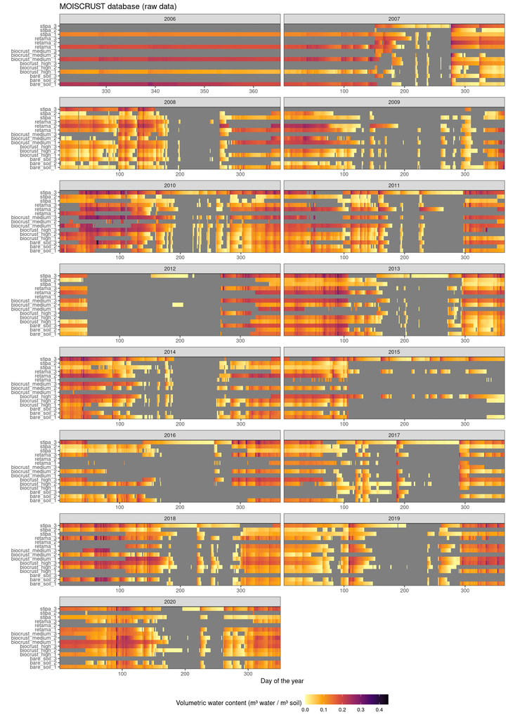

```r
ggplot(moiscrust_long) +
  facet_wrap(
    "year",
    scales = "free_x",
    ncol = 2
    ) +
  aes(
    x = year_day,
    y = sensor,
    fill = soil_moisture
    ) +
  geom_tile() +
  coord_cartesian(expand = FALSE) +
  theme_bw() +
  scale_fill_viridis_c(
    direction = -1,
    na.value = "gray50",
    option = "B"
    ) +
  theme(legend.position = "bottom") +
  ylab("") +
  xlab("Day of the year") +
  ggtitle("MOISCRUST database (raw data)") +
  labs(fill = expression("Volumetric water content (m³ water / m³ soil)")) +
  theme(legend.key.width = unit(1, "cm"))
```

## 3.8 Number of NA per sensor

Due to technical constraints, there is a large number of missing data in the *MOISCRUST* dataset. To better understand the extent of such missing data, the code below counts the number of missing entries per sensor.

```r
#counting NA values per sensor
moiscrust_NA <- moiscrust_long %>%
  group_by(sensor) %>%
  summarise(na_count = sum(is.na(soil_moisture))) %>%
  mutate(na_count_percent = round((na_count * 100) / nrow(moiscrust), 1))

#adding sensor microsite to the moiscrust_NA data frame
moiscrust_NA$microsite <- c(
  "bare_soil",
  "bare_soil",
  "bare_soil",
  "biocrust_high",
  "biocrust_high",
  "biocrust_high",
  "biocrust_medium",
  "biocrust_medium",
  "biocrust_medium",
  "retama",
  "retama",
  "retama",
  "stipa",
  "stipa",
  "stipa"
)

#reordering columns and arranging by na_count
moiscrust_NA <- moiscrust_NA[, c(
  "sensor",
  "microsite",
  "na_count",
  "na_count_percent"
  )] %>%
  dplyr::arrange(na_count) %>%
  as.data.frame()
```

| sensor | microsite | na_count | na_count_percent |
| --- | --- | --- | --- |
| stipa_3 | stipa | 13963 | 30.0 |
| bare_soil_1 | bare_soil | 18442 | 39.6 |
| biocrust_high_2 | biocrust_high | 18813 | 40.4 |
| stipa_1 | stipa | 20840 | 44.8 |
| biocrust_high_1 | biocrust_high | 22940 | 49.3 |
| retama_3 | retama | 24007 | 51.6 |
| biocrust_high_3 | biocrust_high | 24225 | 52.1 |
| biocrust_medium_1 | biocrust_medium | 25797 | 55.5 |
| bare_soil_2 | bare_soil | 27546 | 59.2 |
| stipa_2 | stipa | 27698 | 59.5 |
| biocrust_medium_2 | biocrust_medium | 29532 | 63.5 |
| retama_1 | retama | 30111 | 64.7 |
| biocrust_medium_3 | biocrust_medium | 30596 | 65.8 |
| retama_2 | retama | 31366 | 67.4 |
| bare_soil_3 | bare_soil | 34707 | 74.6 |

# 4 Imputation of missing data

The imputation we apply to fill gaps in *MOISCRUST* works by finding, for a given entry $y$ with missing data at a time $t$, the sensor $x$ with data for $t$ that is in the same type of microsite (if possible), has the longest extent in common, and the highest correlation with the sensor to which $y$ belongs. Then, $y$ is estimated from the linear model $y ~ x$.

## 4.1 Developing criteria to find candidates for gap filling

To generate the criteria to find the best possible candidate *x* to estimate the missing data *y*, we compute the common length and correlation between all pairs of sensors, and generate a column indicating whether they belong to the same microsite or not. With the values stored in these columns we compute a *selection score* based on the following expression:

$$S_{x} = \%vc_{x, y} + (R_{x, y}^2 * 100) + \left\{
\begin{array}{ll}
100, & \mbox{if $microsite_{x} == microsite_{y}$}\\
0, & \mbox{otherwise}
\end{array}
\right.$$

Where:

- $y$ is the sensor with a missing value to be estimated.
- $x$ is the sensor to be used as candidate predictor to estimate the missing value in $y$.
- $S_{x}$ is the selection score of the candidate sensor $x$, in the range [0, 300].
- $\%vc_{x, y}$ is the percent of common valid cases of the sensors $x$ and $y$.
- $R_{x, y}^2$ is the Pearson’s R² of the common valid cases of the sensors $x$ and $y$.
- $microsite_{x}$ and $microsite_{y}$ are the respective microsites of the sensors $x$ and $y$.

During data imputation, for each missing value, the sensor with the higher selection score is used to estimate it.

These criteria are stored in the data frame **sensors_pairs**. Along with the computation of the selection score, the code below also computes a linear model for each pair $x ~ y$, and stores it in the object **sensors_pairs_models**. The identificators of these models are stored in the column *model_id* of the data frame **sensors_pairs**.

```r
#combining sensors in pairs x-y
sensors_pairs <- combn(
  x = sensors,
  m = 2
) %>%
  t() %>%
  as.data.frame()

#adding combinations y-x so all pairs have both directions
#removing repeated pairs
#joining with moiscrust_NA to get sensor groups
#add column same_microsite to check if x and y are or not in the same sensor group
#add empty columns to store % of shared data, model's R squared, and model ID
sensors_pairs <- sensors_pairs %>%
  rbind(
    data.frame(
      V1 = sensors_pairs$V2,
      V2 = sensors_pairs$V1
    )
  ) %>%
  distinct(
    V1,
    V2,
    .keep_all = TRUE
  ) %>%
  left_join(
    moiscrust_NA[, c("sensor", "microsite")],
    by = c("V1" = "sensor")
  ) %>%
  left_join(
    moiscrust_NA[, c("sensor", "microsite")],
    by = c("V2" = "sensor")
  ) %>%
  rename(
    y = V1,
    x = V2,
    y_microsite = microsite.x, #not a mistake
    x_microsite = microsite.y, #not a mistake
  ) %>%
  mutate(
    same_microsite = ifelse(
      x_microsite == y_microsite,
      TRUE,
      FALSE
      ),
    sensors_shared_valid_percent = NA,
    sensors_r_squared = NA,
    model_id = row_number()
  )

#list to store models
sensors_pairs_models <- list()

#looping through sensors pairs to:
#fit lm model y ~ x and save it in sensors_pairs_models
#
for(i in 1:nrow(sensors_pairs)){

  #names of the sensors y and x
  y_i <- sensors_pairs[i, "y"]
  x_i <- sensors_pairs[i, "x"]

  #data of the sensor pair
  sensor_pair_i <- moiscrust[, c(y_i, x_i)]

  #complete cases of the sensor pair
  sensor_pair_i <- sensor_pair_i[complete.cases(sensor_pair_i), ]

  #common cases
  sensors_pairs[i, "sensors_shared_valid_percent"] <-
    nrow(sensor_pair_i) / nrow(moiscrust) * 100

  #R squared of the sensor pair
  sensors_pairs[i, "sensors_r_squared"] <- cor(
    sensor_pair_i[, 1],
    sensor_pair_i[, 2]
    )

  #model formula y ~ x
  formula_i <- as.formula(paste(y_i, "~", x_i))

  #linear model
  sensors_pairs_models[[i]] <- lm(
    formula = formula_i,
    data = sensor_pair_i
  )

}

#selection score to find candidates during gap filling
#(sensors_r_squared * 100) +
#sensors_shared_valid_percent +
#same_microsite (TRUE = 100, FALSE = 0)
sensors_pairs <- mutate(
  sensors_pairs,
  selection_score =
    (sensors_r_squared * 100) +
    sensors_shared_valid_percent +
    ifelse(same_microsite == TRUE, 100, 0)
)

#removing objects we don't need
rm(
  sensor_pair_i,
  formula_i,
  i,
  x_i,
  y_i
)
```

The resulting data frame, named **sensors_pairs**, has columns with the names of the sensor *y* (the one with missing data to impute), the sensor *x* (the candidate to be used as predictor to estimate *y*), their respective microsites, a column indicating if they belong to the same microsite, the percent of shared valid data, the R squared of their shared data, a model ID linking each entry with a model in `sensors_pairs_models`, and a selection score used to select the best possible model to use in the imputation process.

| y | x | y_microsite | x_microsite | same_microsite | sensors_shared_valid_percent | sensors_r_squared | model_id | selection_score |
| --- | --- | --- | --- | --- | --- | --- | --- | --- |
| retama_1 | retama_2 | retama | retama | TRUE | 19.49132 | 0.8875375 | 1 | 208.2451 |
| retama_1 | retama_3 | retama | retama | TRUE | 32.26840 | 0.9050852 | 2 | 222.7769 |
| retama_1 | stipa_1 | retama | stipa | FALSE | 49.39264 | 0.8768781 | 3 | 137.0805 |
| retama_1 | stipa_2 | retama | stipa | FALSE | 30.86449 | 0.8693809 | 4 | 117.8026 |
| retama_1 | stipa_3 | retama | stipa | FALSE | 32.64464 | 0.9077454 | 5 | 123.4192 |
| retama_1 | bare_soil_1 | retama | bare_soil | FALSE | 49.00995 | 0.8918511 | 6 | 138.1951 |
| retama_1 | bare_soil_2 | retama | bare_soil | FALSE | 40.65960 | 0.7716887 | 7 | 117.8285 |
| retama_1 | bare_soil_3 | retama | bare_soil | FALSE | 12.33204 | 0.8942298 | 8 | 101.7550 |
| retama_1 | biocrust_medium_1 | retama | biocrust_medium | FALSE | 45.66465 | 0.9131358 | 9 | 136.9782 |
| retama_1 | biocrust_medium_2 | retama | biocrust_medium | FALSE | 35.28691 | 0.7624165 | 10 | 111.5286 |
| retama_1 | biocrust_medium_3 | retama | biocrust_medium | FALSE | 21.96805 | 0.8633835 | 11 | 108.3064 |
| retama_1 | biocrust_high_1 | retama | biocrust_high | FALSE | 48.26823 | 0.8719324 | 12 | 135.4615 |
| retama_1 | biocrust_high_2 | retama | biocrust_high | FALSE | 43.13633 | 0.8749174 | 13 | 130.6281 |
| retama_1 | biocrust_high_3 | retama | biocrust_high | FALSE | 35.61585 | 0.9401687 | 14 | 129.6327 |
| retama_2 | retama_3 | retama | retama | TRUE | 35.53845 | 0.8520638 | 15 | 220.7448 |
| retama_2 | stipa_1 | retama | stipa | FALSE | 38.00658 | 0.7677740 | 16 | 114.7840 |
| retama_2 | stipa_2 | retama | stipa | FALSE | 38.66016 | 0.8345871 | 17 | 122.1189 |
| retama_2 | stipa_3 | retama | stipa | FALSE | 32.43824 | 0.8913270 | 18 | 121.5709 |
| retama_2 | bare_soil_1 | retama | bare_soil | FALSE | 44.80683 | 0.7984693 | 19 | 124.6538 |
| retama_2 | bare_soil_2 | retama | bare_soil | FALSE | 45.83235 | 0.7608700 | 20 | 121.9193 |

## 4.2 Generating the x and y matrices to impute missing values

During data imputation, two data frames are needed. The data frame **x** contains the data of every sensor for every available time, while the data frame **y**, which starts with empty values, is where the imputed values, their confidence intervals, selection criteria, and other quality-related columns are going to be stored.

```r
#creating data frame of predictors
x <- moiscrust[, sensors]

#creating data frame to store model results
y <- matrix(
  data = NA,
  nrow = nrow(moiscrust),
  ncol = 12
  ) %>%
  as.data.frame()

#new colnames
colnames(y) <- c(
  "interpolated",
  "model_estimate",
  "model_ci_lower",
  "model_ci_upper",
  "model_predictor",
  "same_microsite",
  "sensors_r_squared",
  "sensors_shared_valid_percent",
  "selection_score",
  "date_time_id",
  "sensor",
  "microsite"
  )

#transferring time id
y[, "date_time_id"] <- moiscrust[, "date_time_id"]
y[, "interpolated"] <- FALSE
```

The **x** data frame looks as follows:

| retama_1 | retama_2 | retama_3 | stipa_1 | stipa_2 | stipa_3 | bare_soil_1 | bare_soil_2 | bare_soil_3 | biocrust_medium_1 | biocrust_medium_2 | biocrust_medium_3 | biocrust_high_1 | biocrust_high_2 | biocrust_high_3 |
| --- | --- | --- | --- | --- | --- | --- | --- | --- | --- | --- | --- | --- | --- | --- |
| 0.197 | NA | NA | 0.132 | NA | NA | 0.232 | NA | NA | 0.205 | NA | NA | 0.121 | NA | NA |
| 0.195 | NA | NA | 0.131 | NA | NA | 0.233 | NA | NA | 0.203 | NA | NA | 0.117 | NA | NA |
| 0.194 | NA | NA | 0.131 | NA | NA | 0.234 | NA | NA | 0.203 | NA | NA | 0.117 | NA | NA |
| 0.194 | NA | NA | 0.131 | NA | NA | 0.234 | NA | NA | 0.203 | NA | NA | 0.116 | NA | NA |
| 0.194 | NA | NA | 0.130 | NA | NA | 0.234 | NA | NA | 0.203 | NA | NA | 0.116 | NA | NA |
| 0.194 | NA | NA | 0.130 | NA | NA | 0.234 | NA | NA | 0.202 | NA | NA | 0.116 | NA | NA |
| 0.194 | NA | NA | 0.130 | NA | NA | 0.234 | NA | NA | 0.202 | NA | NA | 0.115 | NA | NA |
| 0.194 | NA | NA | 0.130 | NA | NA | 0.234 | NA | NA | 0.202 | NA | NA | 0.115 | NA | NA |
| 0.194 | NA | NA | 0.130 | NA | NA | 0.234 | NA | NA | 0.202 | NA | NA | 0.115 | NA | NA |
| 0.194 | NA | NA | 0.130 | NA | NA | 0.234 | NA | NA | 0.202 | NA | NA | 0.116 | NA | NA |
| 0.195 | NA | NA | 0.131 | NA | NA | 0.234 | NA | NA | 0.202 | NA | NA | 0.116 | NA | NA |
| 0.195 | NA | NA | 0.131 | NA | NA | 0.233 | NA | NA | 0.201 | NA | NA | 0.115 | NA | NA |
| 0.194 | NA | NA | 0.130 | NA | NA | 0.233 | NA | NA | 0.200 | NA | NA | 0.114 | NA | NA |
| 0.193 | NA | NA | 0.129 | NA | NA | 0.233 | NA | NA | 0.199 | NA | NA | 0.112 | NA | NA |
| 0.192 | NA | NA | 0.129 | NA | NA | 0.234 | NA | NA | 0.199 | NA | NA | 0.111 | NA | NA |
| 0.192 | NA | NA | 0.128 | NA | NA | 0.234 | NA | NA | 0.199 | NA | NA | 0.111 | NA | NA |
| 0.191 | NA | NA | 0.128 | NA | NA | 0.234 | NA | NA | 0.198 | NA | NA | 0.110 | NA | NA |
| 0.190 | NA | NA | 0.127 | NA | NA | 0.234 | NA | NA | 0.198 | NA | NA | 0.109 | NA | NA |
| 0.189 | NA | NA | 0.127 | NA | NA | 0.234 | NA | NA | 0.198 | NA | NA | 0.109 | NA | NA |
| 0.188 | NA | NA | 0.127 | NA | NA | 0.234 | NA | NA | 0.198 | NA | NA | 0.109 | NA | NA |

This is the **y** data frame, that will be filled during the data imputation:

| interpolated | model_estimate | model_ci_lower | model_ci_upper | model_predictor | same_microsite | sensors_r_squared | sensors_shared_valid_percent | selection_score | date_time_id | sensor | microsite |
| --- | --- | --- | --- | --- | --- | --- | --- | --- | --- | --- | --- |
| FALSE | NA | NA | NA | NA | NA | NA | NA | NA | 1 | NA | NA |
| FALSE | NA | NA | NA | NA | NA | NA | NA | NA | 2 | NA | NA |
| FALSE | NA | NA | NA | NA | NA | NA | NA | NA | 3 | NA | NA |
| FALSE | NA | NA | NA | NA | NA | NA | NA | NA | 4 | NA | NA |
| FALSE | NA | NA | NA | NA | NA | NA | NA | NA | 5 | NA | NA |
| FALSE | NA | NA | NA | NA | NA | NA | NA | NA | 6 | NA | NA |
| FALSE | NA | NA | NA | NA | NA | NA | NA | NA | 7 | NA | NA |
| FALSE | NA | NA | NA | NA | NA | NA | NA | NA | 8 | NA | NA |
| FALSE | NA | NA | NA | NA | NA | NA | NA | NA | 9 | NA | NA |
| FALSE | NA | NA | NA | NA | NA | NA | NA | NA | 10 | NA | NA |
| FALSE | NA | NA | NA | NA | NA | NA | NA | NA | 11 | NA | NA |
| FALSE | NA | NA | NA | NA | NA | NA | NA | NA | 12 | NA | NA |
| FALSE | NA | NA | NA | NA | NA | NA | NA | NA | 13 | NA | NA |
| FALSE | NA | NA | NA | NA | NA | NA | NA | NA | 14 | NA | NA |
| FALSE | NA | NA | NA | NA | NA | NA | NA | NA | 15 | NA | NA |
| FALSE | NA | NA | NA | NA | NA | NA | NA | NA | 16 | NA | NA |
| FALSE | NA | NA | NA | NA | NA | NA | NA | NA | 17 | NA | NA |
| FALSE | NA | NA | NA | NA | NA | NA | NA | NA | 18 | NA | NA |
| FALSE | NA | NA | NA | NA | NA | NA | NA | NA | 19 | NA | NA |
| FALSE | NA | NA | NA | NA | NA | NA | NA | NA | 20 | NA | NA |

## 4.3 Data imputation, step by step

The steps to fill the gaps in the **MOISCRUST** database go as follows:

**1.** A given sensor name is selected: “retama_2”

```r
sensor = "retama_2"
```

**2.** The sensors pairs from the table **sensors_pairs** where the selected sensor is *y* (the sensor which values are to be imputed) are selected.

```r
sensors_pair <- sensors_pairs %>%
    dplyr::filter(y == sensor)
```

| y | x | y_microsite | x_microsite | same_microsite | sensors_shared_valid_percent | sensors_r_squared | model_id | selection_score |
| --- | --- | --- | --- | --- | --- | --- | --- | --- |
| retama_2 | retama_3 | retama | retama | TRUE | 35.53845 | 0.8520638 | 15 | 220.7448 |
| retama_2 | stipa_1 | retama | stipa | FALSE | 38.00658 | 0.7677740 | 16 | 114.7840 |
| retama_2 | stipa_2 | retama | stipa | FALSE | 38.66016 | 0.8345871 | 17 | 122.1189 |
| retama_2 | stipa_3 | retama | stipa | FALSE | 32.43824 | 0.8913270 | 18 | 121.5709 |
| retama_2 | bare_soil_1 | retama | bare_soil | FALSE | 44.80683 | 0.7984693 | 19 | 124.6538 |
| retama_2 | bare_soil_2 | retama | bare_soil | FALSE | 45.83235 | 0.7608700 | 20 | 121.9193 |
| retama_2 | bare_soil_3 | retama | bare_soil | FALSE | 29.17034 | 0.8402989 | 21 | 113.2002 |
| retama_2 | biocrust_medium_1 | retama | biocrust_medium | FALSE | 31.35038 | 0.7975457 | 22 | 111.1049 |
| retama_2 | biocrust_medium_2 | retama | biocrust_medium | FALSE | 33.47666 | 0.7376920 | 23 | 107.2459 |
| retama_2 | biocrust_medium_3 | retama | biocrust_medium | FALSE | 27.62454 | 0.8515719 | 24 | 112.7817 |
| retama_2 | biocrust_high_1 | retama | biocrust_high | FALSE | 45.04762 | 0.7545435 | 25 | 120.5020 |
| retama_2 | biocrust_high_2 | retama | biocrust_high | FALSE | 45.04977 | 0.8237431 | 26 | 127.4241 |
| retama_2 | biocrust_high_3 | retama | biocrust_high | FALSE | 31.08808 | 0.8414304 | 27 | 115.2311 |
| retama_2 | retama_1 | retama | retama | TRUE | 19.49132 | 0.8875375 | 106 | 208.2451 |

**3.** The first row of the data frame **x** is selected.

```r
x_row <- x[1, ]
```

| retama_1 | retama_2 | retama_3 | stipa_1 | stipa_2 | stipa_3 | bare_soil_1 | bare_soil_2 | bare_soil_3 | biocrust_medium_1 | biocrust_medium_2 | biocrust_medium_3 | biocrust_high_1 | biocrust_high_2 | biocrust_high_3 |
| --- | --- | --- | --- | --- | --- | --- | --- | --- | --- | --- | --- | --- | --- | --- |
| 0.197 | NA | NA | 0.132 | NA | NA | 0.232 | NA | NA | 0.205 | NA | NA | 0.121 | NA | NA |

**3.1.** If there is a valid value of soil moisture for the sensor “retama_2”, the algorithm goes to the next row, until there is a row with a missing value.

**4.** If there is a missing value (*NA*), the potential candidate predictors are selected from the row by removing the data of other sensors with *NA*, and the data of the target sensor.

```r
predictor_candidates <- as.vector(x[1, ])
predictor_candidates <- predictor_candidates[which(
      !is.na(predictor_candidates) &
        names(predictor_candidates) != sensor
      )]
```

| retama_1 | stipa_1 | bare_soil_1 | biocrust_medium_1 | biocrust_high_1 |
| --- | --- | --- | --- | --- |
| 0.197 | 0.132 | 0.232 | 0.205 | 0.121 |

**5.** From these predictors, the one with the highest selection score is selected from the data frame **sensors_pair** generated in the step **2.**.

```r
best_predictor <- sensors_pair %>%
  dplyr::filter(x %in% names(predictor_candidates)) %>%
  dplyr::arrange(desc(selection_score)) %>%
  dplyr::slice(1)
```

| y | x | y_microsite | x_microsite | same_microsite | sensors_shared_valid_percent | sensors_r_squared | model_id | selection_score |
| --- | --- | --- | --- | --- | --- | --- | --- | --- |
| retama_2 | retama_1 | retama | retama | TRUE | 19.49132 | 0.8875375 | 106 | 208.2451 |

**6.** The model to use, stored in the list **sensors_pairs_model**, is selected from *model_id* column of the **best_predictor** data frame , and used to predict a value for the empty cell.

```r
predict(
  object = sensors_pairs_models[[best_predictor$model_id]],
  newdata = x_row,
  se.fit = TRUE,
  type = "response",
  interval = "confidence"
  )$fit
```

```
##       fit       lwr       upr
## 1 0.24973 0.2477106 0.2517494
```

**7.** The imputed value, its confidence intervals, and other values about the imputation quality available in **best_predictor** are transferred to the same row in the data frame **y**.

**8.** Once all the sensors and rows have been processed this way, the matrix **y** is joined with **moiscrust_long**, and its interpolated values are transferred to the *soil_moisture* column, along with other columns indicating the quality of the interpolation.

## 4.4 Applying the imputation algorithm to the complete dataset

The code below applies the algorithm explained above to every sensor and row with missing data. Sensors are processed in parallel to speed up the data imputation operation.

```r
#setup for parallel execution
temp_cluster <- parallel::makeCluster(
  parallel::detectCores() - 1,
  type = "PSOCK"
)
doParallel::registerDoParallel(cl = temp_cluster)

#parallelized loop (each sensor is processed in one separated thread)
moiscrust_interpolation <- foreach::foreach(
  sensor_i = sensors,
  .packages = c("magrittr", "dplyr")
) %dopar% {

  #subset sensors_pairs
  sensors_pair_i <- sensors_pairs %>%
    dplyr::filter(y == sensor_i)

  #fill microsite
  y[, "microsite"] <- sensors_pair_i$y_microsite[1]

  #scanning the rows of x one by one
  for(row_i in 1:nrow(x)){

    #if is not NA, next iteration
    if(!is.na(x[row_i, sensor_i])){next}

    #getting target row row
    x_row_i <- x[row_i, ]

    #getting predictor candidates available in x_row_i
    predictor_candidates_i <- as.vector(x_row_i)
    predictor_candidates_i <- predictor_candidates_i[which(
      !is.na(predictor_candidates_i) &
        names(predictor_candidates_i) != sensor_i
      )]

    #selecting the predictor candidate with the best selection_score score
    best_predictor_i <- sensors_pair_i %>%
      dplyr::filter(x %in% names(predictor_candidates_i)) %>%
      dplyr::arrange(desc(selection_score)) %>%
      dplyr::slice(1)

    #if there is no best candidate available, next iteration
    if(nrow(best_predictor_i) == 0){next}

    #compute estimates with the model of the best predictor
    prediction <- predict(
        object = sensors_pairs_models[[best_predictor_i$model_id]],
        newdata = x_row_i,
        se.fit = TRUE,
        type = "response",
        interval = "confidence"
        )$fit

    #replacing negative values with 0
    if(prediction[1] < 0){
      prediction[1] <- 0
    }
    if(prediction[2] < 0){
      prediction[2] <- 0
    }
    if(prediction[3] < 0){
      prediction[3] <- 0
    }

    #save prediction
    y[row_i, c(
      "model_estimate",
      "model_ci_lower",
      "model_ci_upper"
      )] <- prediction

    #adding interpolation flag
    y[row_i, "interpolated"] <- TRUE
    y[row_i, "model_predictor"] <- best_predictor_i$x
    y[row_i, "sensors_r_squared"] <- best_predictor_i$sensors_r_squared
    y[row_i, "selection_score"] <- best_predictor_i$selection_score
    y[row_i, "sensors_shared_valid_percent"] <- best_predictor_i$sensors_shared_valid_percent
    y[row_i, "same_microsite"] <- best_predictor_i$same_microsite

  }

  #adding sensor_i name
  y[, "sensor"] <- sensor_i

  return(y)

}

#stop cluster
parallel::stopCluster(temp_cluster)

#removing loop objects
rm(
  x,
  y,
  temp_cluster
)
```

The imputation algorithm produces a list named **moiscrust_interpolation**, with one slot per sensor, each one with one **y** data frame containing the imputation results. Below we transform this object into the data frame **moiscrust_interpolation_long** and join it with **moiscrust_long**, to start preparing the database format.

```r
#naming the output
names(moiscrust_interpolation) <- sensors

#to data frame
moiscrust_interpolation_long <- do.call(
  "rbind",
  moiscrust_interpolation
)

#joining with moiscrust_long
moiscrust_long <- dplyr::left_join(
  moiscrust_long,
  moiscrust_interpolation_long,
  by = c("date_time_id", "sensor")
)

#transferring estimates to the soil_moisture column
moiscrust_long$soil_moisture <- ifelse(
  is.na(moiscrust_long$soil_moisture),
  moiscrust_long$model_estimate,
  moiscrust_long$soil_moisture
)

#adding a interpolation_quality flag following the criteria in the paper
moiscrust_long$interpolation_quality <- moiscrust_long$sensors_r_squared

#filling NA with "observation"
moiscrust_long[
  is.na(moiscrust_long$interpolation_quality),
  "interpolation_quality"
  ] <- 1

#adding NA where there are no values
moiscrust_long[is.na(moiscrust_long$soil_moisture), "interpolation_quality"] <- NA

#computing number of NA cases again
moiscrust_NA <- moiscrust_long %>%
  group_by(sensor) %>%
  summarise(na_count_after = sum(is.na(soil_moisture))) %>%
  mutate(na_count_percent_after = round((na_count_after * 100) / nrow(moiscrust), 1)) %>%
  left_join(
    y = moiscrust_NA,
    by = "sensor"
  ) %>%
  transmute(
    sensor,
    na_count_before = na_count,
    na_count_after,
    na_count_percent_before = na_count_percent,
    na_count_percent_after
  )

#removing moiscrust_interpolation
rm(moiscrust_interpolation)
```

The interpolation has removed all gaps where there was a reference value to interpolate from, as shown in the table below.

| Sensor | NA before interpolation | NA after interpolation | NA % before interpolation | NA % after interpolation |
| --- | --- | --- | --- | --- |
| bare_soil_1 | 18442 | 11338 | 39.6 | 24.4 |
| bare_soil_2 | 27546 | 16872 | 59.2 | 36.3 |
| bare_soil_3 | 34707 | 4191 | 74.6 | 9.0 |
| biocrust_high_1 | 22940 | 12442 | 49.3 | 26.7 |
| biocrust_high_2 | 18813 | 6558 | 40.4 | 14.1 |
| biocrust_high_3 | 24225 | 5640 | 52.1 | 12.1 |
| biocrust_medium_1 | 25797 | 7906 | 55.5 | 17.0 |
| biocrust_medium_2 | 29532 | 9232 | 63.5 | 19.8 |
| biocrust_medium_3 | 30596 | 5509 | 65.8 | 11.8 |
| retama_1 | 30111 | 8967 | 64.7 | 19.3 |
| retama_2 | 31366 | 7529 | 67.4 | 16.2 |
| retama_3 | 24007 | 12216 | 51.6 | 26.3 |
| stipa_1 | 20840 | 10547 | 44.8 | 22.7 |
| stipa_2 | 27698 | 12885 | 59.5 | 27.7 |
| stipa_3 | 13963 | 2049 | 30.0 | 4.4 |

## 4.5 Visualizing the interpolated time series

The **MOISCRUST** database looks as follows after applying the imputation algorithm.

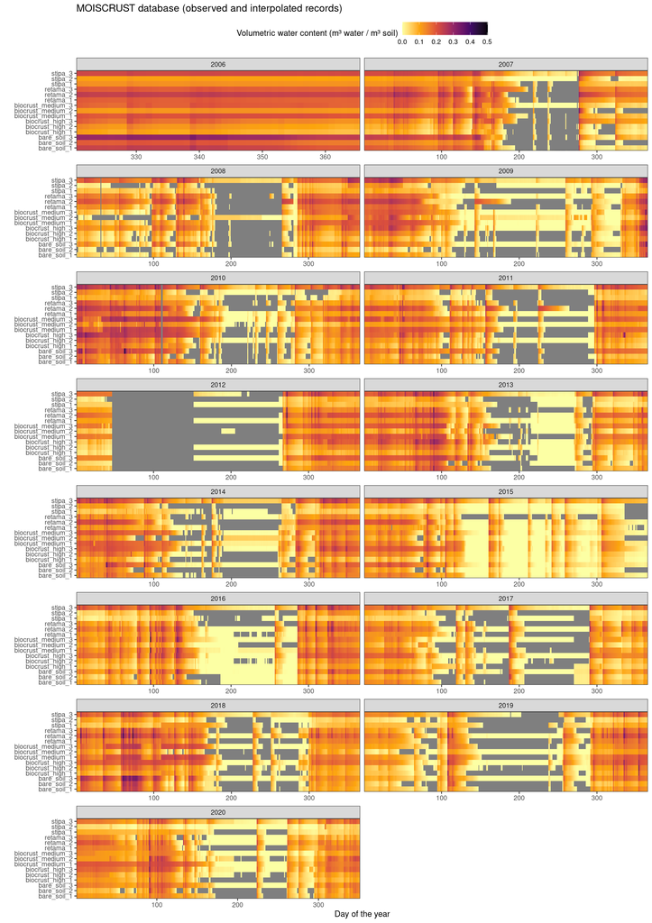

```r
ggplot(moiscrust_long) +
  facet_wrap(
    "year",
    scales = "free_x",
    ncol = 2
    ) +
  aes(
    x = year_day,
    y = sensor,
    fill = soil_moisture
    ) +
  geom_tile() +
  coord_cartesian(expand = FALSE) +
  theme_bw() +
  scale_fill_viridis_c(
    direction = -1,
    na.value = "gray50",
    option = "B"
    ) +
  theme(legend.position = "top") +
  ylab("") +
  xlab("Day of the year") +
  ggtitle("MOISCRUST database (observed and interpolated records)") +
  labs(fill = expression("Volumetric water content (m³ water / m³ soil)")) +
  theme(legend.key.width = unit(0.8, "cm"))
```

The plot above represents both observed and interpolated values. However, the imputation algorithm also generated a new column named *interpolation_quality*, where the observations are marked with the correlation coefficient of the model used to impute each value, as shown in the plot below, where the value `1` (color black) represents actual observations.

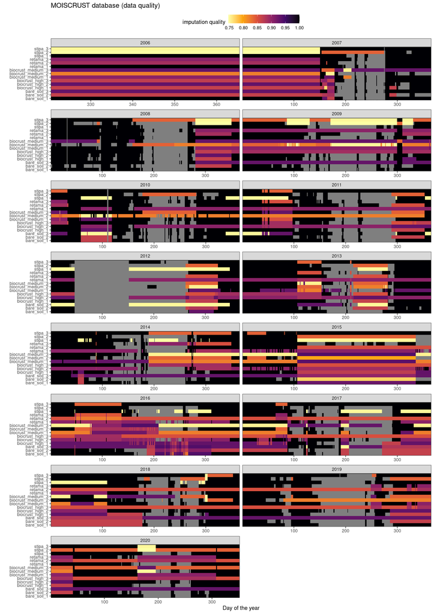

```r
ggplot(moiscrust_long) +
  facet_wrap(
    "year",
    scales = "free_x",
    ncol = 2
    ) +
  aes(
    x = year_day,
    y = sensor,
    fill = interpolation_quality
    ) +
  geom_tile() +
  coord_cartesian(expand = FALSE) +
  theme_bw() +
  scale_fill_viridis_c(
    direction = -1,
    na.value = "gray50",
    option = "B"
    ) +
  theme(legend.position = "top") +
  ylab("") +
  xlab("Day of the year") +
  ggtitle("MOISCRUST database (data quality)") +
  labs(
    fill = expression("imputation quality")) +
  theme(legend.key.width = unit(1, "cm"))
```

# 5 Incorporating weather data at daily resolution

The file `data/daily_weather_aranjuez.csv` contains daily records of solar radiation (daily sum, in $W/m^2$), temperature (maximum and minimum, in ºC), rainfall (daily sum, in mm.), and humidity (in percentage). To join this file with the `moiscrust` dataset, here we import it, aggregate `moiscrust` at daily resolution using only observations, and finally join both datasets by date.

```r
#importing the table
weather <- data.table::fread("data/daily_weather_aranjuez.csv") %>%
  as.data.frame()

#formatting date
weather$date <- format(
  as.POSIXct(
    strptime(
      weather$date,
      "%d/%m/%Y",
      tz = ""
    )
  ),
  format = "%Y-%m-%d"
)

#function to compute the mode of a character vector
char_mode <- function(x){
  x.unique <- unique(na.omit(x))
  x.unique[which.max(tabulate(match(x, x.unique)))]
}

#aggregating moiscrust at daily resolution
moiscrust_daily <- moiscrust_long %>%
  dplyr::group_by(sensor, year, year_day) %>%
  dplyr::summarise(
    date = date[1],
    month = month[1],
    month_day = month_day[1],
    week = week[1],
    week_day = week_day[1],
    microsite = microsite[1],
    soil_moisture_min = suppressWarnings(min(soil_moisture, na.rm = TRUE)),
    soil_moisture_mean = mean(soil_moisture, na.rm = TRUE),
    soil_moisture_max = suppressWarnings(max(soil_moisture, na.rm = TRUE)),
    interpolated = ifelse(sum(interpolated) > 0, TRUE, FALSE),
  ) %>%
  dplyr::filter(interpolated == FALSE) %>%
  dplyr::select(-interpolated) %>%
  as.data.frame()

#NaN to NA
is.nan.data.frame <- function(x){
  do.call(cbind, lapply(x, is.nan))
}
moiscrust_daily[is.nan(moiscrust_daily)] <- NA

#joining by date
moiscrust_weather <- dplyr::left_join(
  moiscrust_daily,
  weather,
  by = "date"
) %>%
  dplyr::select(
    -contains("model_"),
    -year.y,
    -month.y
    ) %>%
  dplyr::rename(
    year = year.x,
    month = month.x,
    temperature_max = temperature_maximum,
    temperature_min = temperature_minimum
  ) %>%
  dplyr::transmute(
    date,
    year,
    year_day,
    season,
    month,
    month_day,
    week,
    week_day,
    sensor,
    microsite,
    soil_moisture_min,
    soil_moisture_mean = round(soil_moisture_mean, 3),
    soil_moisture_max,
    solar_radiation_sum,
    temperature_max,
    temperature_min,
    rainfall_sum,
    humidity_average
  ) %>%
  na.omit()
```

The resulting table, `moiscrust_weather`, has daily observations of soil humidity (not imputed data) coupled with daily weather data.

# 6 Preparing database formats

## 6.1 Format description

### 6.1.1 `moiscrust`

The dataset **moiscrust_long** is the MOISCRUST database in long format Below we rename it to **moiscrust**, reorder its columns, and describe its structure.

```r
moiscrust <- moiscrust_long[ , c(
  "date_time",
  "date_time_id",
  "date",
  "time",
  "year",
  "year_day",
  "month",
  "week",
  "week_day",
  "sensor",
  "microsite",
  "soil_moisture",
  "interpolated",
  "interpolation_quality",
  "model_ci_lower",
  "model_ci_upper",
  "model_predictor",
  "same_microsite",
  "sensors_shared_valid_percent",
  "selection_score"
)]
```

### 6.1.2 `moiscrust_weather`

The `moiscrust_weather` data frame, at daily resolution, has the following columns:

- *date*: date in format year-month-day.
- *year*: integer, year.
- *year_day*: integer, day of the year.
- *season*: character, name of the season.
- *month*: integer, month number.
- *month_day*: integer, day of the month.
- *week*: integer, week of the year.
- *week_day*: integer, day of the week.
- *sensor*: character, sensor name.
- *microsite*: character, name of the microsite.
- *soil_moisture_min*: numeric, minimum soil moisture value for the given day.
- *soil_moisture_mean*: numeric, mean soil moisture for the given day.
- *soil_moisture_max*: numeric, maximum soil moisture registered for the given day.
- *solar_radiation_sum*: numeric, sum of daily solar radiation, in $W/m^2$.
- *temperature_max*: numeric, maximum daily temperature, in $ºC$.
- *temperature_min*: numeric, minimum daily temperature, in $ºC$.
- *rainfall_sum*: numeric, total daily rainfall, in $mm$.
- *humidity_average*: numeric, daily average humidity, in $%$.

## 6.2 Saving the data base in different formats

To expand its usability as much as possible, we provide the data in four different formats: .RData, .csv, .xlsx, and .db (SQLite). The output files are written first to the `database` folder, that is later compressed and named `database.zip`.

```r
#if the zip file does not exists, creates database directory and populates it
if(!file.exists("database.zip")){

  dir.create("database")

  #save as RData
  save(
    moiscrust,
    moiscrust_weather,
    file = "database/moiscrust.RData"
  )

  #save as csv
  readr::write_excel_csv(
    x = moiscrust,
    path = "database/moiscrust.csv"
  )
  readr::write_excel_csv(
    x = moiscrust_weather,
    path = "database/moiscrust_weather.csv"
  )

  #save as excel file
  writexl::write_xlsx(
    x = list(
      moiscrust = moiscrust,
      moiscrust_weather = moiscrust_weather
      ),
    path = "database/moiscrust.xlsx"
  )

  #save as SQLite
  db.driver <- DBI::dbDriver("SQLite")
  db.connection <- DBI::dbConnect(
    db.driver,
    dbname = "database/moiscrust.db"
    )
  DBI::dbWriteTable(
    db.connection,
    "moiscrust",
    moiscrust,
    overwrite = TRUE
    )
    DBI::dbWriteTable(
    db.connection,
    "moiscrust_weather",
    moiscrust_weather,
    overwrite = TRUE
    )
  DBI::dbDisconnect(db.connection)

  #compressing the file
  zip::zipr(
    zipfile = "database.zip",
    files = "database"
  )

}
```